# Team

## Shaun Porwal, M.S.

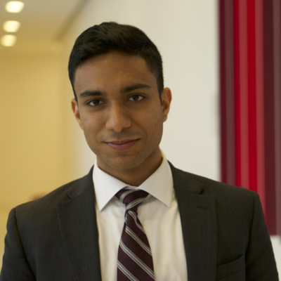

Shaun Porwal, based in New York, is a Biomedical Data Scientist with a B.E. in Biomedical Engineering & Chinese from Rutgers University, and an M.S. in Biomedical Data Science from Mount Sinai. He currently serves as a Data Analyst and Research Biostatistician at Memorial Sloan Kettering Cancer Center. He brought clinical model evaluation to the Python community by writing the ‘dcurves’ package based on Decision Curve Analysis, and routinely contributes to statistical sections in urological cancer publications. Shaun has extensive experience from roles at Sema4 and Rutgers University, developing algorithms for time-series gene expression and performing structural variant detection on large data sets. He’s proficient in several programming languages, including Python & R, and is multilingual, speaking English, Hindi, Mandarin, Japanese, and Spanish. Outside of work, Shaun enjoys learning languages, traveling, and running.

## Matthew Greenberg, M.B.A.

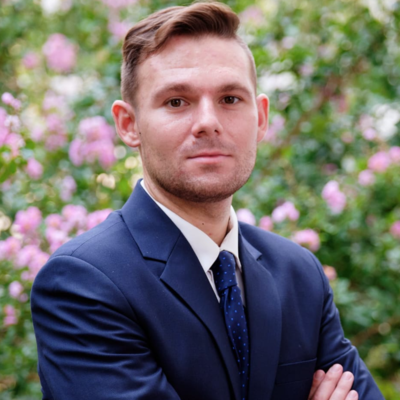

Matthew Greenberg is a business professional experienced in both Product Ownership and Financial Analysis. His experience includes publishing top tier Financial Analysis, including independent work that has been published in numerous financial publications, as well as a distinguished career at Barclays Capital working on two Institutional Investor Ranked Research Teams. As a Product Leader, Matthew has experience at both NRG Energy and Chewy, where he led numerous multi-million dollar initiatives in his roles within Treasury and Category Management. Matthew has an MBA from Emory University and a Bachelors in Finance from Rutgers University.